# Prosody: Experiment 1

# Reading in data

```r
coded = read.csv("../../data/exp1/exp1_critical.csv")
```

# Can people detect a signal, generally?

## Descriptive

```r
mean(coded$correct)
```

```
## [1] 0.7192308
```

```r
sd(coded$correct)
```

```
## [1] 0.449423
```

## Analysis

A **glmer** model predictig *response* from *correct answer* explains more variance than a model without the fixed effect of *correct answer*. (Both models contain random slopes for items and subjects.) In other words, participants are sensitive overall to which utterance was intended as a request.

```r
m1 = glmer(data=coded, response ~ answer + (1 + answer | stimNum) +
             (1 + answer | subject),
           control=glmerControl(optimizer="bobyqa"),
         family=binomial())
```

```
## boundary (singular) fit: see ?isSingular
```

```r
m1.reduced =glmer(data=coded, response ~ (1 + answer | stimNum) +
                    (1 + answer | subject),
                  control=glmerControl(optimizer="bobyqa"),
                    family=binomial())
```

```
## boundary (singular) fit: see ?isSingular
```

```r
anova(m1,m1.reduced)
```

```
## Data: coded
## Models:
## m1.reduced: response ~ (1 + answer | stimNum) + (1 + answer | subject)
## m1: response ~ answer + (1 + answer | stimNum) + (1 + answer | subject)
##            Df    AIC    BIC  logLik deviance  Chisq Chi Df Pr(>Chisq)
## m1.reduced  7 5419.9 5465.0 -2702.9   5405.9
## m1          8 5396.9 5448.5 -2690.4   5380.9 24.968      1   5.83e-07 ***
## ---
## Signif. codes:  0 '***' 0.001 '**' 0.01 '*' 0.05 '.' 0.1 ' ' 1
```

# How does accuracy interact with other factors?

## Analysis

### Building the models

```r
m1 = glmer(data=coded, correct ~ form*speaker + (1 + speaker | stimNum) +
             (1 + form | subject),
           control=glmerControl(optimizer="bobyqa"),
         family=binomial())

m1.reduced =glmer(data=coded, correct ~ form + speaker + (1 + speaker | stimNum) +
                    (1 + form | subject),
                  control=glmerControl(optimizer="bobyqa"),
                    family=binomial())

m1.reduced.form = glmer(data=coded, correct ~ form + (1 + speaker | stimNum) +
                    (1 + form | subject),
                  control=glmerControl(optimizer="bobyqa"),
                    family=binomial())

m1.reduced.speaker = glmer(data=coded, correct ~ speaker + (1 + speaker | stimNum) +
                    (1 + form | subject),
                  control=glmerControl(optimizer="bobyqa"),
                    family=binomial())

m1.null = glmer(data=coded, correct ~ (1 + speaker | stimNum) +
                    (1 + form | subject),
                  control=glmerControl(optimizer="bobyqa"),
                    family=binomial())
```

### Model comparisons

All models constructed with random slopes for effect of speaker per item, and random slopes for effect form per subject.

**Summary**:  
* Model with interaction between *form* and *speaker* explains more variance than model with only fixed effects.  
* Model with both fixed effects better than models with only one (e.g. just form, or just speaker).  
* Models with only form, or only speaker, both better than null model.

```r
anova(m1, m1.reduced)
```

```
## Data: coded
## Models:
## m1.reduced: correct ~ form + speaker + (1 + speaker | stimNum) + (1 + form |
## m1.reduced:     subject)
## m1: correct ~ form * speaker + (1 + speaker | stimNum) + (1 + form |
## m1:     subject)
##            Df    AIC    BIC  logLik deviance  Chisq Chi Df Pr(>Chisq)
## m1.reduced 24 5186.7 5341.6 -2569.4   5138.7
## m1         28 5180.6 5361.2 -2562.3   5124.6 14.125      4   0.006907 **
## ---
## Signif. codes:  0 '***' 0.001 '**' 0.01 '*' 0.05 '.' 0.1 ' ' 1
```

```r
anova(m1.reduced, m1.reduced.form)
```

```
## Data: coded
## Models:
## m1.reduced.form: correct ~ form + (1 + speaker | stimNum) + (1 + form | subject)
## m1.reduced: correct ~ form + speaker + (1 + speaker | stimNum) + (1 + form |
## m1.reduced:     subject)
##                 Df    AIC    BIC  logLik deviance  Chisq Chi Df Pr(>Chisq)
## m1.reduced.form 20 5190.3 5319.3 -2575.1   5150.3
## m1.reduced      24 5186.7 5341.6 -2569.4   5138.7 11.543      4     0.0211
##
## m1.reduced.form
## m1.reduced      *
## ---
## Signif. codes:  0 '***' 0.001 '**' 0.01 '*' 0.05 '.' 0.1 ' ' 1
```

```r
anova(m1.reduced, m1.reduced.speaker)
```

```
## Data: coded
## Models:
## m1.reduced.speaker: correct ~ speaker + (1 + speaker | stimNum) + (1 + form | subject)
## m1.reduced: correct ~ form + speaker + (1 + speaker | stimNum) + (1 + form |
## m1.reduced:     subject)
##                    Df    AIC    BIC  logLik deviance  Chisq Chi Df
## m1.reduced.speaker 23 5189.9 5338.3 -2572.0   5143.9
## m1.reduced         24 5186.7 5341.6 -2569.4   5138.7 5.1891      1
##                    Pr(>Chisq)
## m1.reduced.speaker
## m1.reduced            0.02273 *
## ---
## Signif. codes:  0 '***' 0.001 '**' 0.01 '*' 0.05 '.' 0.1 ' ' 1
```

```r
anova(m1.reduced.form, m1.null)
```

```
## Data: coded
## Models:
## m1.null: correct ~ (1 + speaker | stimNum) + (1 + form | subject)
## m1.reduced.form: correct ~ form + (1 + speaker | stimNum) + (1 + form | subject)
##                 Df    AIC    BIC  logLik deviance  Chisq Chi Df Pr(>Chisq)
## m1.null         19 5193.9 5316.5 -2577.9   5155.9
## m1.reduced.form 20 5190.3 5319.3 -2575.1   5150.3 5.6256      1     0.0177
##
## m1.null
## m1.reduced.form *
## ---
## Signif. codes:  0 '***' 0.001 '**' 0.01 '*' 0.05 '.' 0.1 ' ' 1
```

```r
anova(m1.reduced.speaker, m1.null)
```

```
## Data: coded
## Models:
## m1.null: correct ~ (1 + speaker | stimNum) + (1 + form | subject)
## m1.reduced.speaker: correct ~ speaker + (1 + speaker | stimNum) + (1 + form | subject)
##                    Df    AIC    BIC  logLik deviance  Chisq Chi Df
## m1.null            19 5193.9 5316.5 -2577.9   5155.9
## m1.reduced.speaker 23 5189.9 5338.3 -2572.0   5143.9 11.979      4
##                    Pr(>Chisq)
## m1.null
## m1.reduced.speaker    0.01751 *
## ---
## Signif. codes:  0 '***' 0.001 '**' 0.01 '*' 0.05 '.' 0.1 ' ' 1
```

# Exploratory Analyses

## Effects of order?

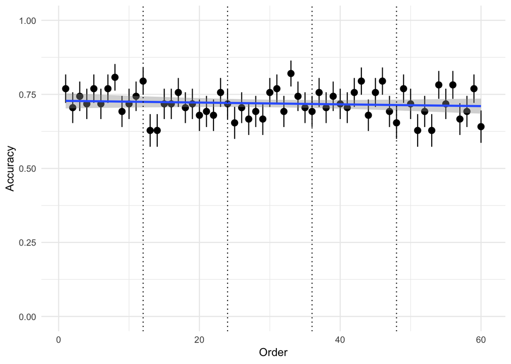

```r
coded %>%
  ggplot(aes(x=Order, y=correct)) +
  geom_point(stat="summary", fun.y="mean") +
  stat_summary (fun.y = function(x){mean(x)},
                fun.ymin = function(x){mean(x) - 1*sd(x)/sqrt(length(x))},
                fun.ymax = function(x){mean(x) + 1*sd(x)/sqrt(length(x))},
                geom= 'pointrange',
                position=position_dodge(width=0.95)) +
  theme_minimal() +
  xlab("Order") +
  ylab("Accuracy") +
  geom_smooth(method = "lm") +
  scale_y_continuous(limits=c(0, 1)) +
  geom_vline(xintercept = c(12, 24, 36, 48), linetype = "dotted")
```

### Analysis

A model with a fixed effect of order explains no more variance in accuracy than a model with no fixed effects.

```r
m1.order =glmer(data=coded, correct ~ Order + (1 | stimNum) +
                    (1 | subject),
                  control=glmerControl(optimizer="bobyqa"),
                  family=binomial())
m1.null =glmer(data=coded, correct ~ (1 | stimNum) +
                    (1 | subject),
                  control=glmerControl(optimizer="bobyqa"),
                  family=binomial())
anova(m1.order,m1.null)
```

```
## Data: coded
## Models:
## m1.null: correct ~ (1 | stimNum) + (1 | subject)
## m1.order: correct ~ Order + (1 | stimNum) + (1 | subject)
##          Df    AIC    BIC  logLik deviance  Chisq Chi Df Pr(>Chisq)
## m1.null   3 5425.3 5444.6 -2709.7   5419.3
## m1.order  4 5426.6 5452.4 -2709.3   5418.6 0.6593      1     0.4168
```

### Order by block

It might also be the case that accuracy improves for each block, but not overall.

Simply adding an interaction between order and speaker won’t directly address whether people improve for a given speaker, because a given speaker could’ve occurred in the first block or the fifth block; this means that the overall trial number (as indexed by *order*) won’t reflect the relative number of the trial *for that speaker* (e.g. comparing trial 11 to trial 24).

Instead, we can *rescale* order to always be between 0-11, e.g. the *order of a trial within a block*. Below, we ask whether the relative order of a trial predicts its accuracy (e.g. whether people improve within each block), and whether this varies by speaker.

Based on model comparisons, we find weak evidence that the order within a block matters. Adding *order_by_block* improves the model over a null model, and over a model including a separate fixed effect for *speaker*. There’s no evidence for an significant interaction between *order_by_block* and *speaker*.

In other words, it is possible that participants improve slightly *within* each block, but they don’t seem to improve overall. The amount that they improve within each block is not dependent on the speaker.

```r
coded$order_by_block = coded$Order %% 12
table(coded$order_by_block)
```

```
##
##   0   1   2   3   4   5   6   7   8   9  10  11
## 390 390 390 390 390 390 390 390 390 390 390 390
```

```r
m1.order_with_speaker_interaction =glmer(data=coded, correct ~ order_by_block * speaker + (1 | stimNum) +
                    (1 | subject),
                  control=glmerControl(optimizer="bobyqa"),
                  family=binomial())

m1.order_plus_speaker =glmer(data=coded, correct ~ order_by_block + speaker + (1 | stimNum) +
                    (1 | subject),
                  control=glmerControl(optimizer="bobyqa"),
                  family=binomial())


m1.only_speaker =glmer(data=coded, correct ~ speaker + (1 | stimNum) +
                    (1 | subject),
                  control=glmerControl(optimizer="bobyqa"),
                  family=binomial())

m1.order_by_block =glmer(data=coded, correct ~ order_by_block + (1 | stimNum) +
                    (1 | subject),
                  control=glmerControl(optimizer="bobyqa"),
                  family=binomial())

m1.null =glmer(data=coded, correct ~ (1 | stimNum) +
                    (1 | subject),
                  control=glmerControl(optimizer="bobyqa"),
                  family=binomial())

anova(m1.order_with_speaker_interaction, m1.order_plus_speaker)
```

```
## Data: coded
## Models:
## m1.order_plus_speaker: correct ~ order_by_block + speaker + (1 | stimNum) + (1 | subject)
## m1.order_with_speaker_interaction: correct ~ order_by_block * speaker + (1 | stimNum) + (1 | subject)
##                                   Df    AIC    BIC  logLik deviance  Chisq
## m1.order_plus_speaker              8 5338.5 5390.1 -2661.2   5322.5
## m1.order_with_speaker_interaction 12 5343.2 5420.6 -2659.6   5319.2 3.2801
##                                   Chi Df Pr(>Chisq)
## m1.order_plus_speaker
## m1.order_with_speaker_interaction      4     0.5121
```

```r
anova(m1.order_plus_speaker, m1.only_speaker)
```

```
## Data: coded
## Models:
## m1.only_speaker: correct ~ speaker + (1 | stimNum) + (1 | subject)
## m1.order_plus_speaker: correct ~ order_by_block + speaker + (1 | stimNum) + (1 | subject)
##                       Df    AIC    BIC  logLik deviance  Chisq Chi Df
## m1.only_speaker        7 5339.7 5384.9 -2662.9   5325.7
## m1.order_plus_speaker  8 5338.5 5390.1 -2661.2   5322.5 3.2538      1
##                       Pr(>Chisq)
## m1.only_speaker
## m1.order_plus_speaker    0.07126 .
## ---
## Signif. codes:  0 '***' 0.001 '**' 0.01 '*' 0.05 '.' 0.1 ' ' 1
```

```r
anova(m1.order_by_block, m1.null)
```

```
## Data: coded
## Models:
## m1.null: correct ~ (1 | stimNum) + (1 | subject)
## m1.order_by_block: correct ~ order_by_block + (1 | stimNum) + (1 | subject)
##                   Df    AIC    BIC  logLik deviance Chisq Chi Df
## m1.null            3 5425.3 5444.6 -2709.7   5419.3
## m1.order_by_block  4 5424.2 5450.0 -2708.1   5416.2 3.085      1
##                   Pr(>Chisq)
## m1.null
## m1.order_by_block    0.07902 .
## ---
## Signif. codes:  0 '***' 0.001 '**' 0.01 '*' 0.05 '.' 0.1 ' ' 1
```

# Discussion

Key takeaways:

Overall, listeners are able to detect which of two utterances was intended as a request. This suggests that speakers are capable of producing discriminable cues when asked to.

Analysis of accuracy by *order* suggests that participants didn’t improve overall as the experiment went on. However, analysis of *within-block order* provides weak evidence that participants may improve slightly within each speaker-block; the magnitude of this improvement did not seem to depend on the particular speaker. In other words, participants don’t get better at detecting intent *in general* over the course of the study, but *for each speaker*, they may improve over the course of those 12 trials. If this is true, it suggests that participants can **adapt** to a given speaker, but that this adaptation may not transfer to new speakers. (This seems at odds with the observation that similar acoustic features are predictive intent *across* speakers.)